# EM for Mixtures of t-Distributions

Computational Statistics, Assignment 3, topic B

## Roadmap

1. **A simple implementation** the formulas coded directly, on the density scale, with R’s `dt()`
2. **Is it correct?** a test against `optim()`
3. **Where is it slow?** profiling with `Rprof` and `profvis`
4. **A faster implementation** a log-scale version with a shorter first step in the line search, and an S3 design with two classes so the two implementations share the same GEM code
5. **How good is it?** `bench::press` against R’s own optimizers

# A simple implementation

## Two-component mixture of $t$-distributions

$$f(x \mid \theta) = p\, f(x \mid \mu_1, \sigma_1^2, \nu_1) + (1 - p)\, f(x \mid \mu_2, \sigma_2^2, \nu_2),
\qquad \theta = (p, \mu_1, \mu_2, \sigma_1, \sigma_2)$$

with $f(x \mid \mu, \sigma^2, \nu) = \frac{\Gamma((\nu+1)/2)}{\sqrt{\pi\nu\sigma^2}\,\Gamma(\nu/2)}\left(1 + \frac{(x-\mu)^2}{\nu\sigma^2}\right)^{-(\nu+1)/2}$ and $\nu_1, \nu_2$ fixed.

Simulated data as in the assignment:

```r
set.seed(42)
nu <- c(5, 10)
par_true <- c(p = 0.6, mu1 = 0, mu2 = 3,
              sigma1 = 1, sigma2 = 0.7)
x <- rtmix(400, par_true, nu)
par0 <- default_start(x)
round(par0, 3)
```

```
#> [1]  0.500 -0.464  2.831  0.974  0.974
```

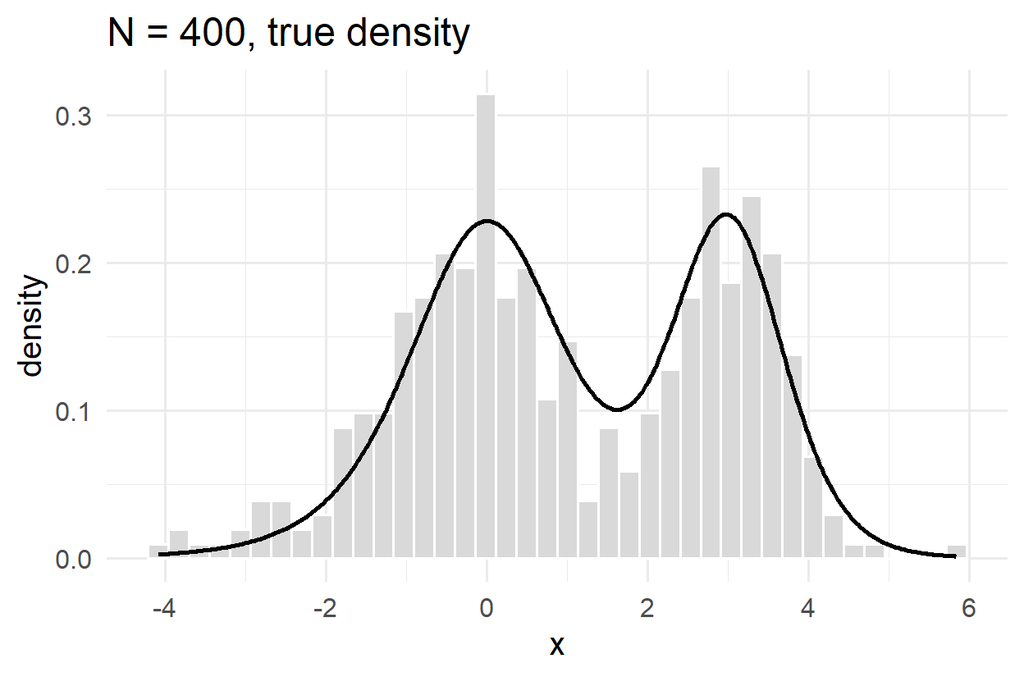

## Missing data: the component labels

**Idea:** if we knew which component each $x_i$ came from, estimation would be easy just like the two coins in lecture 9.

Introduce the (unobserved) label $Z_i \in \{1, 2\}$:
$$P(Z_i = 1) = p, \qquad X_i \mid Z_i = j \sim t(\mu_j, \sigma_j^2, \nu_j).$$

Write $f_j(x) = f(x \mid \mu_j, \sigma_j^2, \nu_j)$. The joint density of one complete observation $(x_i, z_i)$ is
$$f(x_i, z_i \mid \theta) = \big(p\, f_1(x_i)\big)^{\mathbf{1}(z_i = 1)} \big((1 - p)\, f_2(x_i)\big)^{\mathbf{1}(z_i = 2)}.$$

**Check:** summing over $z_i \in \{1, 2\}$ gives $p f_1(x_i) + (1-p) f_2(x_i)$ exactly the mixture density. So $(X, Z)$ is a valid complete-data model for our observed $X$.

**Complete-data log-likelihood** (what we could maximize if $Z$ were observed):
$$\ell_c(\theta) = \sum_{i=1}^N \mathbf{1}(Z_i = 1)\big(\log p + \log f_1(x_i)\big) + \mathbf{1}(Z_i = 2)\big(\log(1-p) + \log f_2(x_i)\big)$$

## E-step: from $\ell_c$ to $Q$

$Q(\theta \mid \hat\theta) = E_{\hat\theta}\big(\ell_c(\theta) \mid X = x\big)$ average $\ell_c$ over what the labels could be, given the data and the current guess $\hat\theta$.

**Step 1 linearity.** Given $x$, the terms $\log p + \log f_1(x_i)$ are just numbers, so the expectation only hits the indicators:
$$E_{\hat\theta}\big(\mathbf{1}(Z_i = 1) \mid X = x\big) = P_{\hat\theta}(Z_i = 1 \mid X_i = x_i) =: \gamma_i$$

**Step 2 Bayes’ formula.** With $\hat f_j$ the density of component $j$ at the current guess $(\hat\mu_j, \hat\sigma_j)$:
$$\gamma_i = \frac{P(Z_i = 1)\, f(x_i \mid Z_i = 1)}{f(x_i)} = \frac{\hat p\, \hat f_1(x_i)}{\hat p\, \hat f_1(x_i) + (1 - \hat p)\, \hat f_2(x_i)}$$

**Result:**
$$Q(\theta \mid \hat\theta) = \sum_{i=1}^N \gamma_i \big(\log p + \log f_1(x_i)\big) + (1 - \gamma_i)\big(\log(1-p) + \log f_2(x_i)\big)$$

## M-step: maximize $Q$ what can be solved?

$Q$ splits into three parts that can be maximized separately:
$$Q = \underbrace{\sum_i \gamma_i \log p + (1 - \gamma_i)\log(1-p)}_{\text{only } p}
+ \underbrace{\sum_i \gamma_i \log f_1(x_i)}_{\text{only } \mu_1, \sigma_1}
+ \underbrace{\sum_i (1 - \gamma_i) \log f_2(x_i)}_{\text{only } \mu_2, \sigma_2}$$

**$p$:** $\ \partial_p Q = \frac{\sum_i \gamma_i}{p} - \frac{N - \sum_i \gamma_i}{1 - p} = 0 \;\Rightarrow\; p = \frac{1}{N}\sum_i \gamma_i$ closed form.

**$(\mu_1, \sigma_1)$:** a *weighted* $t$ log-likelihood. With $r = x - \mu_1$ and $\log f_1(x) = c(\nu_1) - \log \sigma_1 - \frac{\nu_1 + 1}{2}\log\big(1 + \frac{r^2}{\nu_1 \sigma_1^2}\big)$, the chain rule gives
$$\partial_{\mu_1} \log f_1(x) = \frac{w\, r}{\sigma_1^2},
\qquad
\partial_{\sigma_1} \log f_1(x) = -\frac{1}{\sigma_1} + \frac{w\, r^2}{\sigma_1^3},
\qquad w = \frac{\nu_1 + 1}{\nu_1 + r^2/\sigma_1^2},$$
so
$$\partial_{\mu_1} Q = \sum_i \gamma_i \frac{w_{i1} r_{i1}}{\sigma_1^2}, \qquad
\partial_{\sigma_1} Q = \sum_i \frac{\gamma_i}{\sigma_1}\left(\frac{w_{i1} r_{i1}^2}{\sigma_1^2} - 1\right) \qquad (\text{component 2: } 1 - \gamma_i).$$

Setting $\partial_{\mu_1} Q = 0$ and $\partial_{\sigma_1} Q = 0$ gives
$$\mu_1 = \frac{\sum_i \gamma_i w_{i1} x_i}{\sum_i \gamma_i w_{i1}}, \qquad
\sigma_1^2 = \frac{\sum_i \gamma_i w_{i1} r_{i1}^2}{\sum_i \gamma_i}$$
but $w_{i1}$ depends on $\mu_1$ and $\sigma_1$ themselves: fixed-point equations, not formulas.

## One gradient step but how long?

First iteration from `par0`: E-step, update $p$, and then move a step of length $s$ along the gradient, $\theta + s\, g$. How much does $Q$ change?

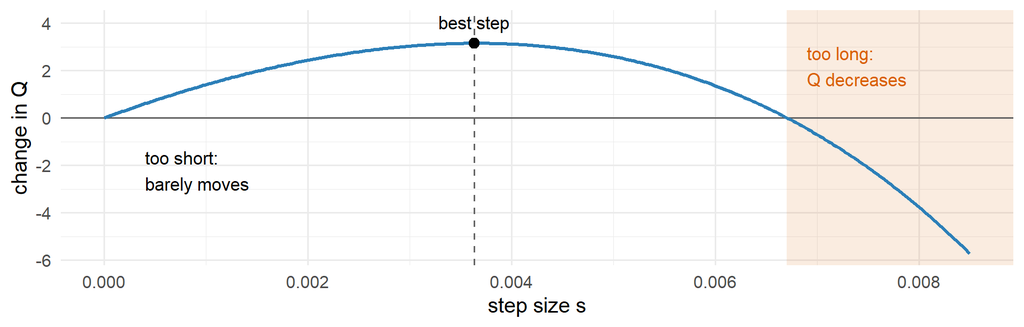

**Solution backtracking:** start with a long step and halve it until $Q$ has increased enough (Armijo condition $Q(\theta + s g) \ge Q(\theta) + c\, s\, \|g\|^2$).

## Running it

```r
fit <- gem(x, nu)
fit
```

```
#>        p      mu1      mu2   sigma1   sigma2
#>  0.61669 -0.21856  3.06146  1.03538  0.59891
#> attr(,"iter")
#> [1] 24
```

```r
loglik(fit, x, nu)
```

```
#> [1] -779.35
```

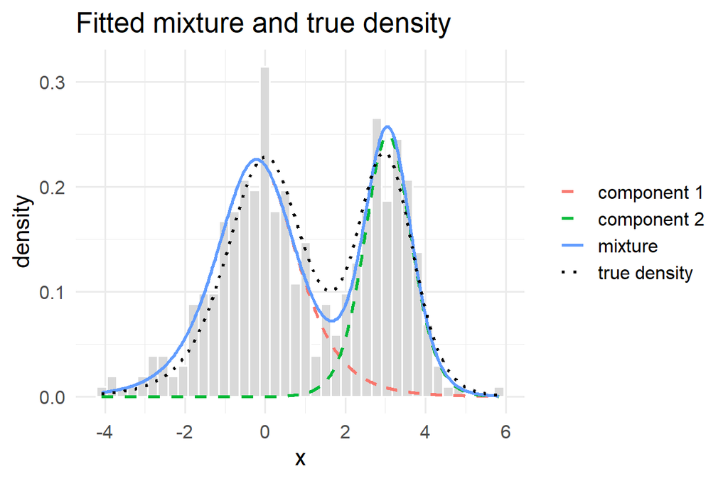

# Is it correct?

## A test against `optim()`

`optim()` is R’s general-purpose optimizer. It maximizes the observed log-likelihood $\ell(\theta)$ directly. If the GEM is implemented correctly, the two must find the same maximum.

Both are started at the same point (`default_start()`):

|  | $p$ | $\mu_1$ | $\mu_2$ | $\sigma_1$ | $\sigma_2$ | $\ell(\hat\theta)$ |
| --- | --- | --- | --- | --- | --- | --- |
| GEM | 0.6167 | -0.2185 | 3.0615 | 1.0354 | 0.5989 | -779.3512 |
| optim() (BFGS) | 0.6167 | -0.2185 | 3.0615 | 1.0354 | 0.5989 | -779.3512 |
| Difference | 1.5e-07 | 4.7e-07 | 2.0e-07 | 4.4e-07 | 1.4e-07 | 1.9e-11 |

Two different algorithms agree on the estimate and on the log-likelihood.

# Where is it slow?

## Why? Number of calls × cost per call

The profile says *where* the time goes. To see *why*, count how often each building block is called in one fit ($N = 5000$, 30 iterations) and time a single call with `bench::mark`:

[output not shown]

- One call to `Q()` costs about the same as one E-step but `Q()` is called **10.7 times per iteration**, the E-step once.
- `dt_ls()` is not an extra cost: it is the density inside `Q()` and `e_step()` (2 calls in each), so its row overlaps with theirs.
- The gradient is almost free.

## Conclusion: two hotspots

1. **The line search.** $Q$ is evaluated 10.7 times per iteration (322 calls in 30 iterations), because the backtracking restarts from step size 1 in *every* iteration and needs about 9 halvings before the step is short enough ($\approx 2^{-9}$).
2. **`dt()`.** Most of the time is spent inside R’s `dt()`. Every $Q$ and every E-step evaluates the $t$-density twice for all $N$ points: 704 density evaluations of length 5000 per fit.

## Does the starting point matter?

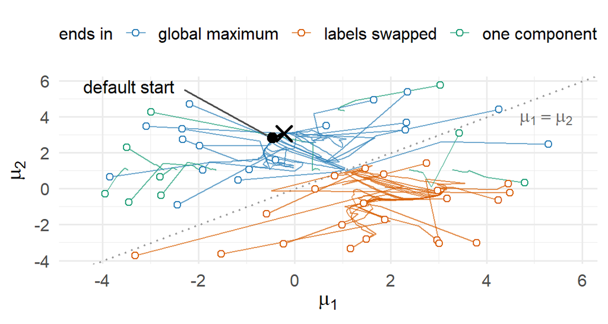

**50 starting points:** `default_start(x)` and 49 random ones, $p \sim U(0.1, 0.9)$, $\mu_j \sim U(\min x, \max x)$, $\sigma_j \sim \mathrm{sd}(x) \cdot U(0.2, 2)$.

**Do they all find the maximum? No.**

- **19 of 50** end at the same estimate as the default start ($\times$), $\ell = -779.35$.
- **22** end at a local maximum with the labels swapped, $\ell = -780.74$: not the same fit, because $\nu_1 \neq \nu_2$.
- **9** collapse to one component ($p \to 0$ or $1$).

## Does the step size matter?

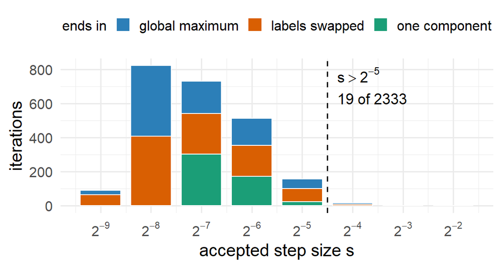

**How long are the accepted steps?** Only 19 of 2333 are longer than $2^{-5}$, wherever the fit starts and ends. The same 50 fits with a shorter first step in the backtracking:

| First step | Evaluations of $Q$ | Iterations |
| --- | --- | --- |
| $1$ | 17978 | 2333 |
| **$2^{-5}$** | **9369** | **2320** |
| $2^{-8}$ | 5303 | 2635 |

# A faster implementation: the log scale

## From the profile to a plan

**What the profile showed:** `Q()` takes 91% of the time, and `dt()` alone 88%.

**Observation:** $Q$ only needs **log**-densities,
$$Q(\theta \mid \hat\theta) = \sum_i \gamma_i \big(\log p + \log f_1(x_i)\big) + (1 - \gamma_i)\big(\log(1-p) + \log f_2(x_i)\big),$$
but version 1 computes the density with `dt()` and then takes `log()` of it .

**And hotspot 1:** the line search now starts at $s = 2^{-5}$ instead of $1$.

## The S3 design: two classes with a common parent

[figure not shown]

**`tmix`** (parent) holds what is the same for both:

- the data `x` and the shape parameters `nu`
- `grad_Q()`: the gradient is the same formula
- `fit()`: the GEM algorithm

**`tmix_density`**: `loglik()`, `e_step()` and `Q()` with slow `dt()`.

**`tmix_log`**: A new version of the 3 methods using log density, and the constant $c(\nu)$ stored in the object.

## One GEM algorithm for both classes

The GEM fit is slighty modified to take model as input, so the same `fit()` works for both classes.

Make the two models and fit them:

```r
model_d <- tmix_density(x, nu)   # density scale, dt()
model_l <- tmix_log(x, nu)       # log scale

rbind(density = fit(model_d),
      log     = fit(model_l))
```

```
#>               p      mu1    mu2 sigma1  sigma2
#> density 0.61669 -0.21856 3.0615 1.0354 0.59891
#> log     0.61669 -0.21856 3.0615 1.0354 0.59891
```

## Do the two classes agree?

The density class is the tested version 1, so the log class is tested against it:

```r
par_test <- c(0.4, -0.5, 2.5, 1.3, 0.9)
gam_test <- e_step(model_d, par0)

test_that("the log class computes the same as the density class", {
  expect_equal(loglik(model_l, par_test), loglik(model_d, par_test))
  expect_equal(e_step(model_l, par_test), e_step(model_d, par_test))
  expect_equal(Q(model_l, par_test, gam_test), Q(model_d, par_test, gam_test))
  expect_equal(fit(model_l), fit(model_d), tolerance = 1e-8)
})
```

```
#> Test passed with 4 successes 😸.
```

## Is it faster?

The two classes timed with `bench::mark` on the data from the profiling ($N = 5000$). `bench::mark` also checks that both give the same estimate.

|  | `tmix_density` (ms) | `tmix_log` (ms) | Speed-up |
| --- | --- | --- | --- |
| **Whole fit** | **712** | **201** | **3.5 ×** |
| One call to `Q()` | 4.23 | 0.59 | 7.1 × |
| One call to `e_step()` | 3.80 | 0.64 | 5.9 × |
| One call to `loglik()` | 2.35 | 0.93 | 2.5 × |

- The whole fit is **3.5 times faster** on log scale, with the same estimate and the same number of iterations. Both classes start the line search at $2^{-5}$, so this is the effect of the log scale alone.

## Where is the time now?

Profiling comparison

| Function | Calls per fit, version 1 | Calls per fit, version 2 | Share of time, version 1 | Share of time, version 2 |
| --- | --- | --- | --- | --- |
| **`Q()`** | **322** | **240** | **91%** | **72%** |
| `e_step()` | 30 | 30 | 7% | 20% |
| `grad_Q()` | 30 | 30 | 1% | 5% |

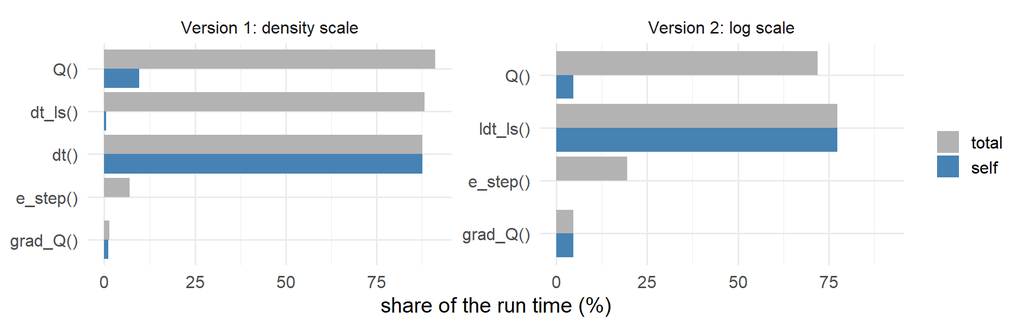

- **Fewer calls and cheaper calls:** starting at $2^{-5}$ saves 3 evaluations of $Q$ per iteration 8 instead of 10.7, with the same 30 iterations.

# How good is it? Benchmark against R’s optimizers

## The competitors

R has several general-purpose optimizers. They do not use the EM idea: they maximize the observed log-likelihood $\ell(\theta)$ directly.

| Method | Function | Type |
| --- | --- | --- |
| GEM | `fit()` (ours) | E-step + one gradient step on $Q$ with backtracking |
| BFGS | `optim(method = "BFGS")` | quasi-Newton |
| L-BFGS-B | `optim(method = "L-BFGS-B")` | quasi-Newton, limited memory |
| CG | `optim(method = "CG")` | conjugate gradient |
| Nelder-Mead | `optim(method = "Nelder-Mead")` | simplex, uses no gradient |
| nlminb | `nlminb()` | quasi-Newton (PORT library) |

## Do they all find the same maximum?

On the data from the profiling ($N = 5000$):

| Method | $p$ | $\mu_1$ | $\mu_2$ | $\sigma_1$ | $\sigma_2$ | Evaluations | Distance to best $\ell$ |
| --- | --- | --- | --- | --- | --- | --- | --- |
| **GEM (ours)** | 0.6031 | 0.0044 | 2.9831 | 0.9949 | 0.7031 | 30 | 1.3e-05 |
| BFGS | 0.6032 | 0.0046 | 2.9832 | 0.9950 | 0.7030 | 47 | 7.6e-09 |
| L-BFGS-B | 0.6032 | 0.0046 | 2.9832 | 0.9950 | 0.7030 | 13 | 4.4e-09 |
| CG | 0.6032 | 0.0046 | 2.9832 | 0.9950 | 0.7030 | 241 | 0 |
| Nelder-Mead | 0.6032 | 0.0045 | 2.9831 | 0.9950 | 0.7031 | 348 | 7.9e-06 |
| nlminb | 0.6032 | 0.0045 | 2.9832 | 0.9950 | 0.7030 | 41 | 1.2e-07 |

Evaluations: iterations for the GEM, function evaluations for the others.

## `bench::press`: time as a function of $N$

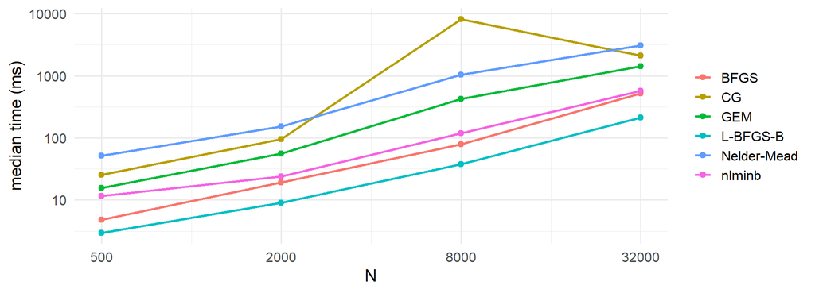

## Why is the GEM slower than the quasi-Newton methods?

All the methods spend their time the same way: on passes over the data in the same R functions. So the speed is decided by **how many passes** a method needs.

- **The GEM takes many small steps.** It follows the gradient, which only gives a direction, and converges slowly: 30 iterations for $N = 5000$.
- **Each step is expensive.** The step length has to be found by trial and error, about 8 evaluations of $Q$ per iteration.
- **The quasi-Newton methods take few, good steps.** They also use the curvature, so they know both the direction and how far to go.

# Robustness: $t$ mixture vs Gaussian mixture

## A Gaussian mixture for comparison

The assignment suggests comparing the location and scale estimates with those from a two-component **Gaussian** mixture, in particular with outliers in the sample. The Gaussian mixture has a closed-form M-step, so it is an ordinary EM algorithm, run with the same driver `em()`.

Contaminate the sample from before ($N = 400$) with 10 outliers $\pm U(8, 20)$, i.e. 2.4% of the data, and fit both models from the same starting value (the true parameters):

|  | $p$ | $\mu_1$ | $\mu_2$ | $\sigma_1$ | $\sigma_2$ |
| --- | --- | --- | --- | --- | --- |
| True parameters | 0.60 | 0.00 | 3.00 | 1.00 | 0.70 |
| $t$ mixture, clean | 0.62 | -0.22 | 3.06 | 1.04 | 0.60 |
| Gaussian mixture, clean | 0.61 | -0.26 | 3.09 | 1.24 | 0.66 |
| $t$ mixture, 10 outliers | 0.68 | -0.07 | 3.12 | 1.39 | 0.54 |
| Gaussian mixture, 10 outliers | 0.78 | 0.41 | 3.09 | 3.20 | 0.48 |

## The two fits on the contaminated sample

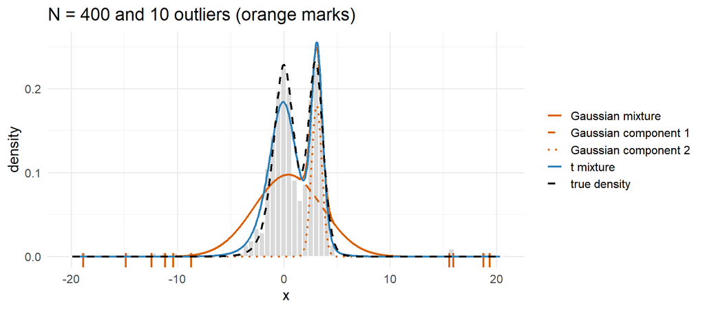

- The Gaussian mixture has no heavy tails, so the only way it can give the outliers a positive likelihood is to **widen component 1** ($\sigma_1 = 3.20$). That component now lies under the whole sample, its mean is pulled to 0.41, and it takes weight from component 2 ($p = 0.78$).
- The result is that the left mode has disappeared: the fitted Gaussian density is far too low around 0 and too high on the flanks, where there are almost no data.
- The $t$ mixture keeps both modes and stays much closer to the true density: its tails already allow for a few far-away observations, so it only widens component 1 a little.

## Estimates as a function of the number of outliers

20 simulated data sets ($N = 400$). To each, add $k$ outliers $\pm U(8, 20)$ and fit both mixtures, started at the true parameters so that only the *models* differ:

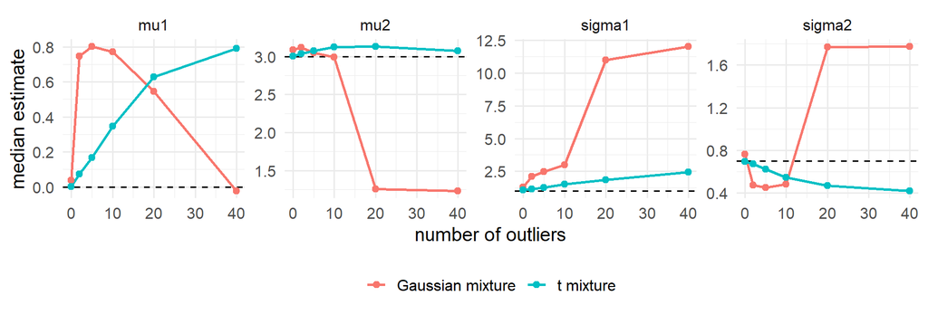

Median estimate over the 20 data sets; the dashed lines are the true values.

- **Without outliers** the two models agree on the locations, but the Gaussian mixture overestimates $\sigma_1$ (1.29 against the true 1): it has to explain the heavy tails of the $t_5$ component with a larger variance.
- **Two outliers (0.5%) are enough** to move the Gaussian $\sigma_1$ to 2.09 and $\mu_1$ to 0.75; the $t$ mixture gives 1.14 and 0.07.
- **With 20 or more outliers the Gaussian mixture breaks down**: one component is used for the outliers alone ($\sigma_1 \approx 11$) and the other has to cover both real components.
- The $t$ mixture degrades gradually instead. With fixed $\nu$ it is not immune: $\sigma_1$ still grows with the number of outliers.